# applied_statistics_project

```python
# PART B
# 1. Read the data set, clean the data and prepare final dataset to be used for analysis.
basketball.info()
```

```
<class 'pandas.core.frame.DataFrame'>
RangeIndex: 61 entries, 0 to 60
Data columns (total 13 columns):
 #   Column               Non-Null Count  Dtype
---  ------               --------------  -----
 0   Team                 61 non-null     object
 1   Tournament           61 non-null     int64
 2   Score                61 non-null     object
 3   PlayedGames          61 non-null     object
 4   WonGames             61 non-null     object
 5   DrawnGames           61 non-null     object
 6   LostGames            61 non-null     object
 7   BasketScored         61 non-null     object
 8   BasketGiven          61 non-null     object
 9   TournamentChampion   61 non-null     object
 10  Runner-up            61 non-null     object
 11  TeamLaunch           61 non-null     object
 12  HighestPositionHeld  61 non-null     int64
dtypes: int64(2), object(11)
memory usage: 6.3+ KB
```

```python
# PART B
# 1. Read the data set, clean the data and prepare final dataset to be used for analysis.
basketball.shape
```

```
(61, 13)
```

```python
# PART B
# 1. Read the data set, clean the data and prepare final dataset to be used for analysis.
basketball.describe()
```

|  | Tournament | HighestPositionHeld |
| --- | --- | --- |
| count | 61.000000 | 61.000000 |
| mean | 24.000000 | 7.081967 |
| std | 26.827225 | 5.276663 |
| min | 1.000000 | 1.000000 |
| 25% | 4.000000 | 3.000000 |
| 50% | 12.000000 | 6.000000 |
| 75% | 38.000000 | 10.000000 |
| max | 86.000000 | 20.000000 |

```python
# PART B
# 1. Read the data set, clean the data and prepare final dataset to be used for analysis.
# Data cleaning level 1

# replace - with 0 in number related fields
basketball.replace(to_replace='-', value=0, inplace=True)

# for team launch to get start year only got first 4 digits
basketball['TeamLaunch'] = basketball['TeamLaunch'].str[:4]
basketball.head(10)
```

|  | Team | Tournament | Score | PlayedGames | WonGames | DrawnGames | LostGames | BasketScored | BasketGiven | TournamentChampion | Runner-up | TeamLaunch | HighestPositionHeld |
| --- | --- | --- | --- | --- | --- | --- | --- | --- | --- | --- | --- | --- | --- |
| 0 | Team 1 | 86 | 4385 | 2762 | 1647 | 552 | 563 | 5947 | 3140 | 33 | 23 | 1929 | 1 |
| 1 | Team 2 | 86 | 4262 | 2762 | 1581 | 573 | 608 | 5900 | 3114 | 25 | 25 | 1929 | 1 |
| 2 | Team 3 | 80 | 3442 | 2614 | 1241 | 598 | 775 | 4534 | 3309 | 10 | 8 | 1929 | 1 |
| 3 | Team 4 | 82 | 3386 | 2664 | 1187 | 616 | 861 | 4398 | 3469 | 6 | 6 | 1931 | 1 |
| 4 | Team 5 | 86 | 3368 | 2762 | 1209 | 633 | 920 | 4631 | 3700 | 8 | 7 | 1929 | 1 |
| 5 | Team 6 | 73 | 2819 | 2408 | 990 | 531 | 887 | 3680 | 3373 | 1 | 4 | 1934 | 1 |
| 6 | Team 7 | 82 | 2792 | 2626 | 948 | 608 | 1070 | 3609 | 3889 | 0 | 0 | 1929 | 3 |
| 7 | Team 8 | 70 | 2573 | 2302 | 864 | 577 | 861 | 3228 | 3230 | 2 | 3 | 1929 | 1 |
| 8 | Team 9 | 58 | 2109 | 1986 | 698 | 522 | 766 | 2683 | 2847 | 0 | 1 | 1939 | 2 |
| 9 | Team 10 | 51 | 1884 | 1728 | 606 | 440 | 682 | 2159 | 2492 | 1 | 0 | 1932 | 1 |

```python
# PART B
# 1. Read the data set, clean the data and prepare final dataset to be used for analysis.
# Data cleaning level 2

# converted all number fields into interger which datatypes were object
fields = basketball.columns
basketball[fields[1:]] = basketball[fields[1:]].astype('int64')
basketball.info()
```

```
<class 'pandas.core.frame.DataFrame'>
RangeIndex: 61 entries, 0 to 60
Data columns (total 13 columns):
 #   Column               Non-Null Count  Dtype
---  ------               --------------  -----
 0   Team                 61 non-null     object
 1   Tournament           61 non-null     int64
 2   Score                61 non-null     int64
 3   PlayedGames          61 non-null     int64
 4   WonGames             61 non-null     int64
 5   DrawnGames           61 non-null     int64
 6   LostGames            61 non-null     int64
 7   BasketScored         61 non-null     int64
 8   BasketGiven          61 non-null     int64
 9   TournamentChampion   61 non-null     int64
 10  Runner-up            61 non-null     int64
 11  TeamLaunch           61 non-null     int64
 12  HighestPositionHeld  61 non-null     int64
dtypes: int64(12), object(1)
memory usage: 6.3+ KB
```

```python
# PART B
# 1. Read the data set, clean the data and prepare final dataset to be used for analysis.
# Data cleaning level 3

# Adding few new fields
# win percentage field
winning_percentage = basketball['WonGames'] / basketball['PlayedGames']
basketball.insert(loc=5, column='WinPercentage', value=winning_percentage)
basketball.head()
```

|  | Team | Tournament | Score | PlayedGames | WonGames | WinPercentage | DrawnGames | LostGames | BasketScored | BasketGiven | TournamentChampion | Runner-up | TeamLaunch | HighestPositionHeld |
| --- | --- | --- | --- | --- | --- | --- | --- | --- | --- | --- | --- | --- | --- | --- |
| 0 | Team 1 | 86 | 4385 | 2762 | 1647 | 0.596307 | 552 | 563 | 5947 | 3140 | 33 | 23 | 1929 | 1 |
| 1 | Team 2 | 86 | 4262 | 2762 | 1581 | 0.572411 | 573 | 608 | 5900 | 3114 | 25 | 25 | 1929 | 1 |
| 2 | Team 3 | 80 | 3442 | 2614 | 1241 | 0.474751 | 598 | 775 | 4534 | 3309 | 10 | 8 | 1929 | 1 |
| 3 | Team 4 | 82 | 3386 | 2664 | 1187 | 0.445571 | 616 | 861 | 4398 | 3469 | 6 | 6 | 1931 | 1 |
| 4 | Team 5 | 86 | 3368 | 2762 | 1209 | 0.437726 | 633 | 920 | 4631 | 3700 | 8 | 7 | 1929 | 1 |

PART B:

1. Perform detailed statistical analysis and EDA using univariate, bi-variate and multivariate EDA techniques to get data driven insights on recommending which teams they can approach which will be a deal win for them. Also as a data and statistics expert you have to develop a detailed performance report using this data. [10 Marks] Hint: Use statistical techniques and visualisation techniques to come up with useful metrics and reporting. Find out the best performing team, oldest team, team with highest goals, team with lowest performance etc. and many more. These are just random examples. Please use your best analytical approach to build this report. You can mix match columns to create new ones which can be used for better analysis. Create your own features if required. Be highly experimental and analytical here to find hidden patterns. Use graphical interactive libraries to enable you to publish interactive plots in python.

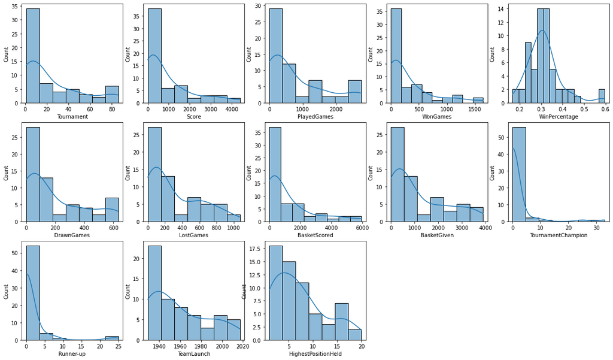

```python
# PART B
# 2.
# Univariate analysis
# Creating histplot for each fields/columns
fields = basketball.columns[1:]
plt.figure(figsize=(20,20))
i = 1
for col in basketball[fields]:
    plt.subplot(5,5,i);
    sns.histplot(data=basketball,x=basketball[col], kde=True);
    i += 1
```

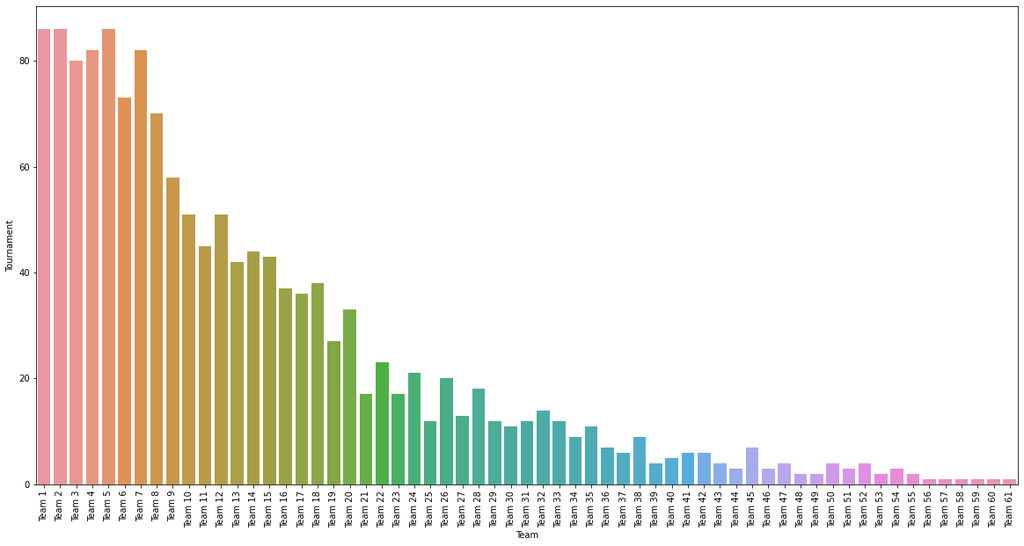

```python
# PART B
# 2.
# Bivariate analysis
# Creating barplot for checking team vs tournament
# No of tournaments played by teams
plt.figure(figsize=(20,10))
sns.barplot(x=basketball['Team'], y=basketball['Tournament']);
plt.xticks(rotation=90);
```

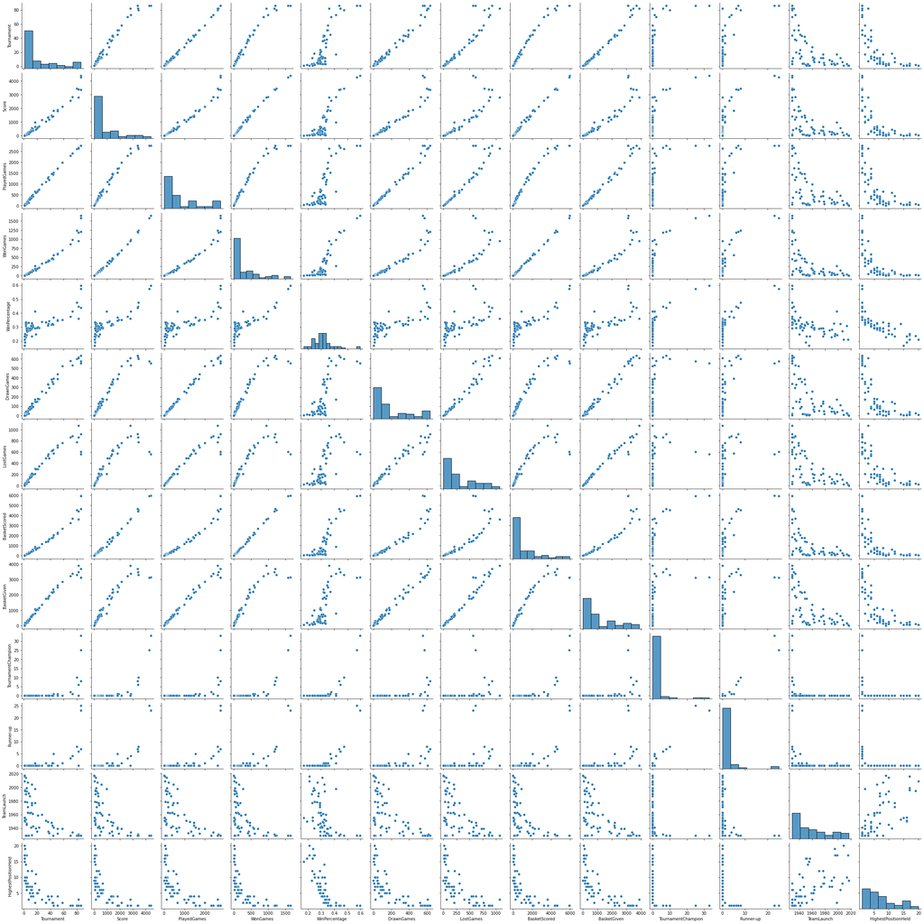

```python
# PART B
# 2.
# multivariate analysis
# creating pairplot for all fields data
sns.pairplot(basketball[fields]);
plt.show();
```

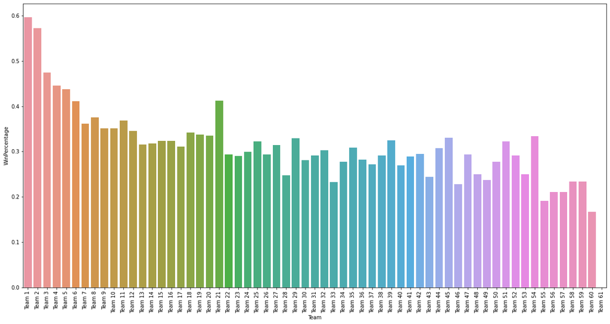

```python
# PART B
# 2.
# team performance in terms of win percentage
# creating barplot for team vs. win percentage
plt.figure(figsize=(20,10))
sns.barplot(x=basketball['Team'], y=basketball['WinPercentage']);
plt.xticks(rotation=90);
```

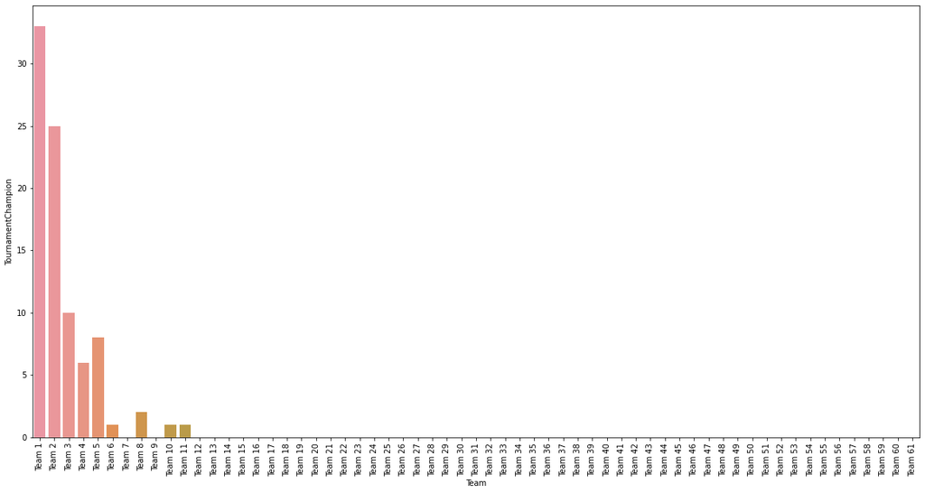

```python
# PART B
# 2.
# creating barplot for team vs. win percentage
plt.figure(figsize=(20,10))
sns.barplot(x=basketball['Team'], y=basketball['TournamentChampion']);
plt.xticks(rotation=90);
```

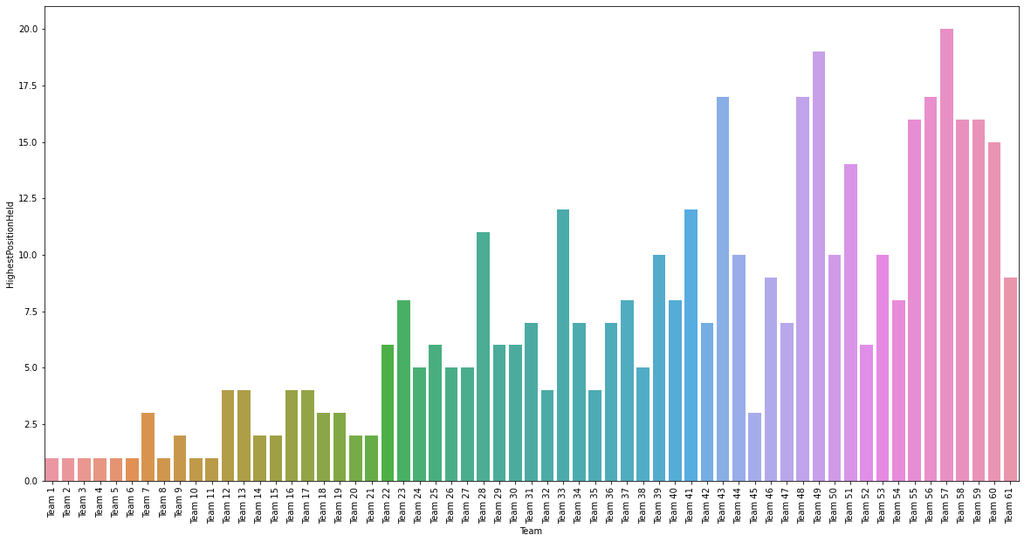

```python
# PART B
# 2.
# creating barplot for team vs. win percentage
plt.figure(figsize=(20,10))
sns.barplot(x=basketball['Team'], y=basketball['HighestPositionHeld']);
plt.xticks(rotation=90);
```

[figure not shown]

```python
# PART B
# 2.
# No of matches won by teams
plt.figure(figsize=(20,8))
plt.pie(basketball["WonGames"], labels=basketball["Team"].value_counts().index,autopct='%1.1f%%');
plt.title('no. of matches won')
```

[figure not shown]

```python
# PART B
# 2.
# No of matches lost by teams
plt.figure(figsize=(20,8))
plt.pie(basketball["LostGames"], labels=basketball["Team"].value_counts().index,autopct='%1.1f%%');
plt.title('no. of matches lost')
```

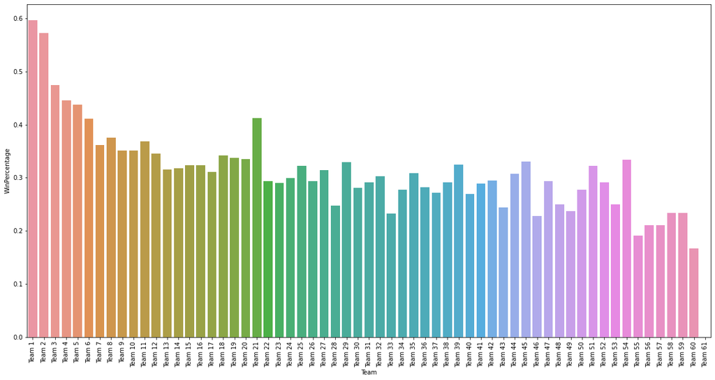

```python
# PART B
# 2.
# team performance in terms of win percentage
# creating barplot for team vs. win percentage
plt.figure(figsize=(20,10))
sns.barplot(x=basketball['Team'], y=basketball['WinPercentage']);
plt.xticks(rotation=90);
```

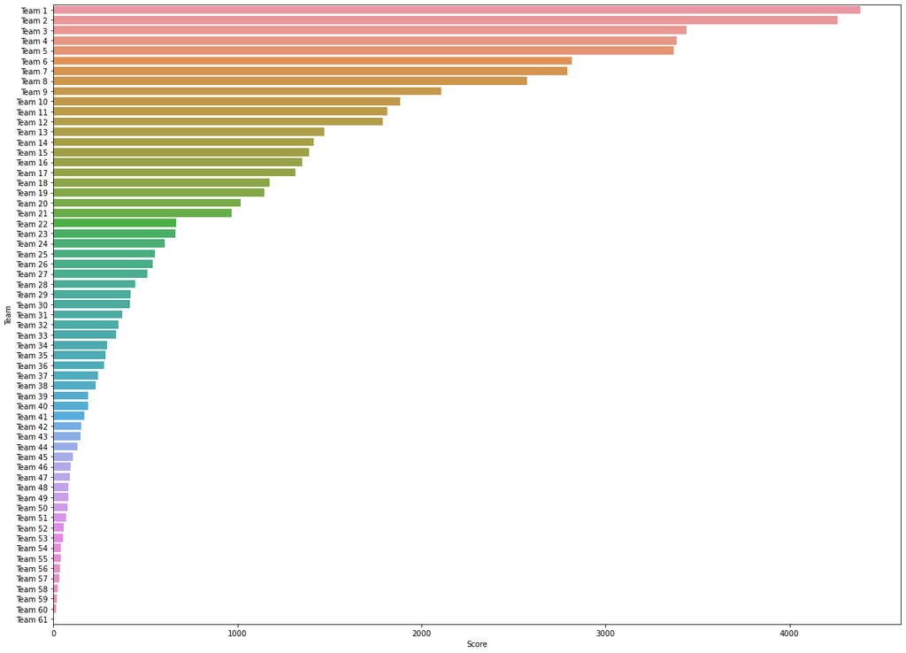

```python
# PART B
# 2.
# Scores of the teams
plt.figure(figsize=(20,15))
sns.barplot(x=basketball['Score'], y=basketball['Team']);
```

# PART B # 3. Please include any improvements or suggestions to the association management on quality, quantity, variety, velocity, veracity etc. on the data points collected by the association to perform a better data analysis in future. At-least 1 suggestion for each point. # Number of teams should have been little less to plot graphs(specially piecharts) since this is dummy data. # If fields contains number only, data type should be integer or float instead of object. # Few more fields(example: team country/state, team is male/female team etc. or any other object fields for handling more categorical data) could have been added. # Some wrong data(we can consider as noise in data) is there in dataset. For example: Team 61 is holding a position in HighestPositionHeld, but other fields don't have data. This looks wrong. # Dataset should contain some updated and latest details also based on more match played. Based on that one more field could be introduced as LastMatchPlayed or something similar.

```python
# PART A
# Please refer the table below to answer below questions:
# 1.A. Refer above table and find the joint probability of the people who planned to purchase and actually placed an order.
prob1 = 400/2000
print(prob1)
# 1.B. Refer to the above table and find the joint probability of the people who planned to purchase and actually placed an order, given that people planned to purchase.
prob2 = (400 / 2000 )/ (500 / 2000)
print(prob2)
```

```
0.2
0.8
```

```python
# PART A
# An electrical manufacturing company conducts quality checks at specified periods on the products it manufactures. Historically, the failure rate for the manufactured item is 5%. Suppose a random sample of 10 manufactured items is selected. Answer the following questions.
p = 0.05
n = 10
k = np.arange(0,11)
result = stats.binom.pmf(k,n,p)
print(result)
# 2.A. Probability that none of the items are defective?
print('first output: %f' %result[0])
# 2.B. Probability that exactly one of the items is defective?
print('second output: %f' %result[1])
#2.C. Probability that two or fewer of the items are defective?
cumbinomial = stats.binom.cdf(k,n,p)
print('third output: %f' %cumbinomial[2])
# 2.D. Probability that three or more of the items are defective ?
# P(2) = ¹⁰C3(0.05)3(0.95)7
p = 1- cumbinomial[2]
print('third output: %f' %p)
```

```
[5.98736939e-01 3.15124705e-01 7.46347985e-02 1.04750594e-02
 9.64808106e-04 6.09352488e-05 2.67259863e-06 8.03789062e-08
 1.58642578e-09 1.85546875e-11 9.76562500e-14]
first output: 0.598737
second output: 0.315125
third output: 0.988496
third output: 0.011504
```

```python
# PART A
# A car salesman sells on an average 3 cars per week. [3 Marks]
# 3.A. What is Probability that in a given week he will sell some cars? [1 Mark]
# probability will be p(x > 0)
# p(x > 0) = 1 - p(x0)
mu = 3
p = stats.poisson.pmf(k=0,mu=mu)
poisson = 1 - p
print(poisson)
# 3.B. What is Probability that in a given week he will sell 2 or more but less than 5 cars? [1 Mark]
# probability will be P(2≤X<5)
print(sum(stats.poisson.pmf(k=[2,3,4],mu=mu)))
```

```
0.950212931632136
0.6161149710523164
```

[figure not shown]

```python
# PART A
# A car salesman sells on an average 3 cars per week. [3 Marks]
# 3.C. Plot the poisson distribution function for cumulative probability of cars sold per-week vs number of cars sold per week.
plt.plot(0, p, 'o-')
plt.title('Poisson')
plt.xlabel('Number of Cars')
plt.show()
```

```python
# PART A
# 4. Accuracy in understanding orders for a speech based bot at a restaurant is important for the Company X which has designed, marketed and launched the product for a contactless delivery due to the COVID-19 pandemic. Recognition accuracy that measures the percentage of orders that are taken correctly is 86.8%. Suppose that you place an order with the bot and two friends of yours independently place orders with the same bot. Answer the following questions. [3 Marks]
p   =  0.868 # percentage of orders filled correctly at Wendy's was approximately 86.8%
n   =  3
k   =  np.arange(0,4)
binomial = stats.binom.pmf(k,n,p)
print(binomial)
# 4.A. What is the probability that all three orders will be recognised correctly? [1 Mark]
print("first output: %f" %binomial[3])
# 4.B. What is the probability that none of the three orders will be recognised correctly? [1 Mark]
print("second output: %f" %binomial[0])
# 4.C. What is the probability that at least two of the three orders will be recognised correctly? [1 Mark]
cumbinomial = stats.binom.cdf(k,n,p)
P = 1 - cumbinomial[1]
print("third output: %f" %P)
```

```
[0.00229997 0.0453721  0.2983559  0.65397203]
first output: 0.653972
second output: 0.002300
third output: 0.952328
```

```
cdf: 0.500000
ppf: 3.000000
pmf: 0.246094
```

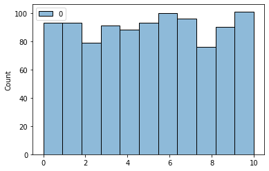

```python
# PART A
#5. Explain 1 real life industry scenario (other than the ones mentioned above) where you can use the concepts learnt in this module of Applied Statistics to get data driven business solution.
# Creating 1000 numbers from one uniform distribution
data = stats.uniform.rvs(size=1000, loc=0, scale=10)
pd_df = pd.DataFrame(data)
sns.histplot(data=pd_df)
print('cdf: %f' %(stats.uniform.cdf(x=5.0, loc=0, scale=10)))
print('ppf: %f' %(stats.uniform.ppf(q=0.3, loc=0, scale=10)))
print('pmf: %f' %(stats.binom.pmf(k=5, n=10, p=0.5)))
```